# Project 03

## Solutions

This document gives solutions to the questions posed in Project 3. I had a bit of fun with some of these, and included additional tweaks that make the output look a bit nicer. These were not expected in my grading of the projects.

## Prompts

### 1. Spatial Extent

**Question** Show a spatial visualization (i.e., a map) of the infection rate (cases per population) in the U.S. on 1 May 2020, 15 June 2020, and 1 October for the “lower 48” states (no Hawaii, Alaska, or Puerto Rico). Also, separately show the infection rate for Hawaii on 15 June 2020. Try to describe the patterns in a few short sentences. Make sure to use appropriate projections and color scales.

**Solution Notes** I included explicit limits in the color scale in order to make the maps comparable to one another. For Hawaii, I manually set the limits of the x and y axes to zoom in on the actual data (there must be a better way to do this automatically, but I could not figure out how). I also included thick outlines for Hawaii; these are often too busy for counties but look nice when looking at island chains.

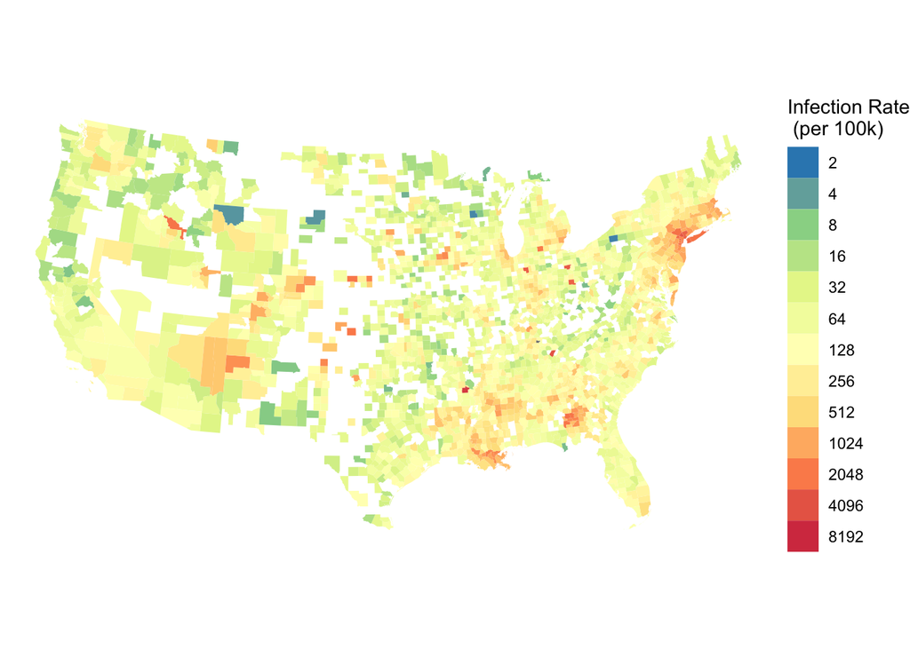

```r
county %>%
  inner_join(filter(covid, date == "2020-05-01"), by = c("fips", "state")) %>%
  inner_join(demog, by = c("fips", "state")) %>%
  mutate(infect_rate = cases / population * 100000) %>%
  filter(!(state %in% c("HI", "AK", "PR"))) %>%
  st_transform(3083) %>%
  ggplot() +
    geom_sf(aes(fill = infect_rate), size = 0) +
    scale_fill_distiller(
      trans = "log2", palette = "Spectral", guide = "legend", n.breaks = 10,
      limits = c(2, 8192)
    ) +
    labs(fill = "Infection Rate\n (per 100k)") +
    theme_void()
```

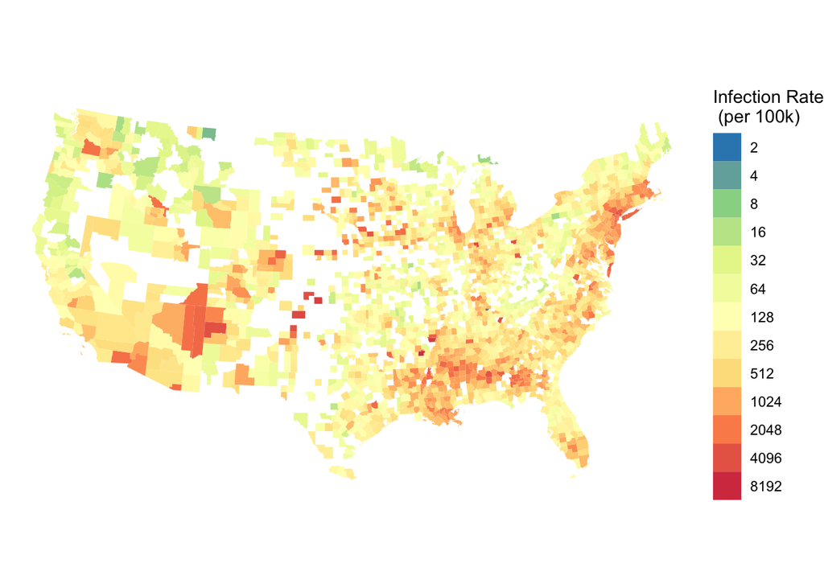

```r
county %>%
  inner_join(filter(covid, date == "2020-06-15"), by = c("fips", "state")) %>%
  inner_join(demog, by = c("fips", "state")) %>%
  mutate(infect_rate = cases / population * 100000) %>%
  filter(!(state %in% c("HI", "AK", "PR"))) %>%
  st_transform(3083) %>%
  ggplot() +
    geom_sf(aes(fill = infect_rate), size = 0) +
    scale_fill_distiller(
      trans = "log2", palette = "Spectral", guide = "legend", n.breaks = 10,
      limits = c(2, 8192)
    ) +
    labs(fill = "Infection Rate\n (per 100k)") +
    theme_void()
```

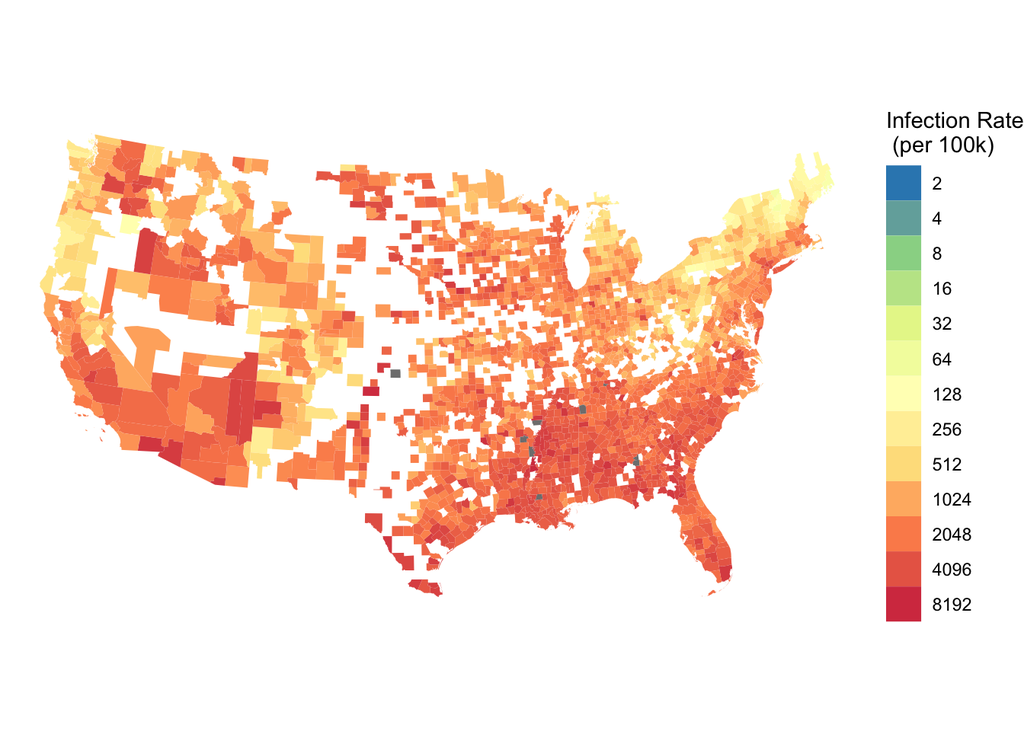

```r
county %>%
  inner_join(filter(covid, date == "2020-10-01"), by = c("fips", "state")) %>%
  inner_join(demog, by = c("fips", "state")) %>%
  mutate(infect_rate = cases / population * 100000) %>%
  filter(!(state %in% c("HI", "AK", "PR"))) %>%
  st_transform(3083) %>%
  ggplot() +
    geom_sf(aes(fill = infect_rate), size = 0) +
    scale_fill_distiller(
      trans = "log2", palette = "Spectral", guide = "legend", n.breaks = 10,
      limits = c(2, 8192)
    ) +
    labs(fill = "Infection Rate\n (per 100k)") +
    theme_void()
```

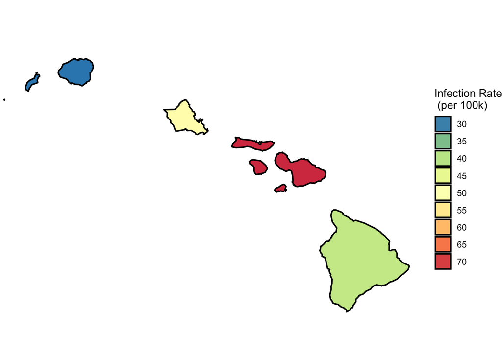

```r
county %>%
  inner_join(filter(covid, date == "2020-06-15"), by = c("fips", "state")) %>%
  inner_join(demog, by = c("fips", "state")) %>%
  mutate(infect_rate = cases / population * 100000) %>%
  filter(state == "HI") %>%
  st_transform(26961) %>%
  ggplot() +
    geom_sf(aes(fill = infect_rate), size = 0.7, color = "black") +
    scale_fill_distiller(
      palette = "Spectral", guide = "legend", n.breaks = 10
    ) +
    labs(fill = "Infection Rate\n (per 100k)") +
    coord_sf(xlim = c(0, 572762.8), ylim = c(8500, 400000)) +
    theme_void()
```

### 2. Political Party

**Question** How does the general political affiliation at the county level relate to the observed case fatality rate (cases / deaths) and the overall infection rate (cases / population)? Answer the question on a month-by-month basis (i.e., compute the rates for each month separately, not cumulatively) and plot these showing the change over time.

**Solution Notes** Several students asked a good question about whether we should compute the infection and fatality rates for each county and then take an average, or add together the deaths and cases and compute the rates on the entire data. The later is the better choice because it correctly weights the counties by their overall population. A small technical detail is that I filtered the data to only the first day of the month and then used the lead function, so that I have the counts for the ongoing month. I did it this way because R puts the month label on the first day of the month. Depending on your approach, you plot may be off-set by a month in relation to the labels on the x-axis.

```r
party_data <- covid %>%
  filter(day(date) == 1) %>%
  inner_join(demog, by = c("fips", "state")) %>%
  group_by(fips) %>%
  mutate(
    deaths_new = lead(deaths) - deaths,
    cases_new = lead(cases) - cases,
    party = if_else(per_gop_2016 > per_dem_2016, "R", "D")
  ) %>%
  filter(!is.na(cases_new), !is.na(deaths_new)) %>%
  group_by(date, party) %>%
  summarize(
    n = n(),
    inf_rate = sum(cases_new) / sum(population),
    case_fat_rate = sum(deaths_new) / sum(cases_new)
  )
```

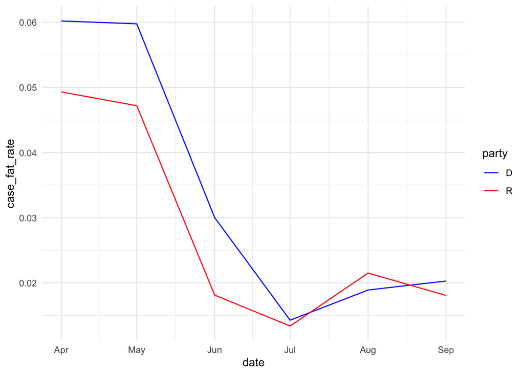

```r
party_data %>%
  ggplot(aes(date, case_fat_rate)) +
    geom_line(aes(color = party)) +
    scale_color_manual(values = c("blue", "red"))
```

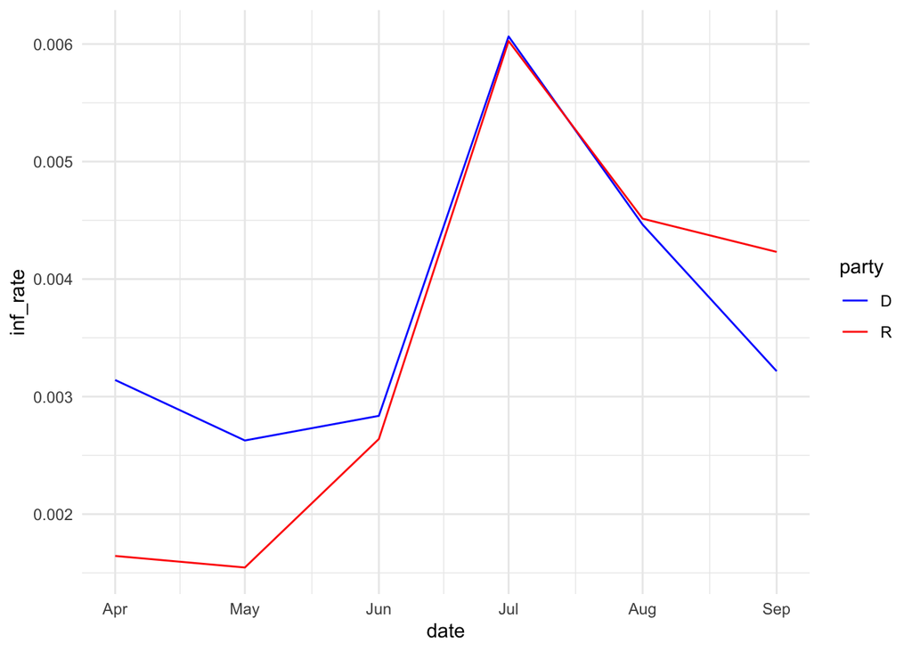

```r
party_data %>%
  ggplot(aes(date, inf_rate)) +
    geom_line(aes(color = party)) +
    scale_color_manual(values = c("blue", "red"))
```

### 3. Largest Counties

**Question** Visualize the number of new cases in the 8 largest counties over the time range of the entire dataset for each day using a 7-day moving average.

**Solution Notes** I had to change the original question because the 9th largest county is Kings County (Brooklyn). New York only reports city-wide data, so this caused missing values to appear in the data. In my solution, I added on a layer we never learned called a facet wrap. This create a number of small plots, broken out by a new variable. Do not overuse this feature (that is why I never showed it in class), but it can produce very nice visualizations in the right situations.

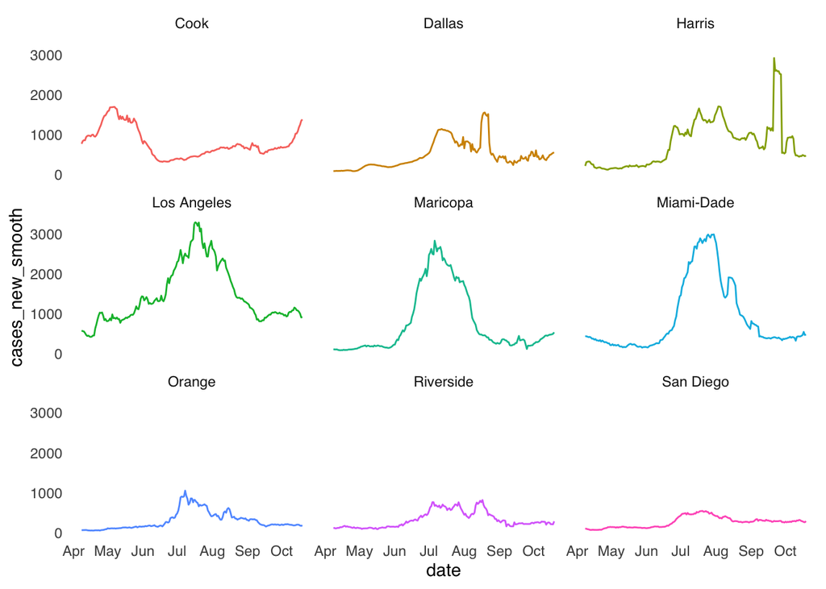

```r
top_counties <- demog %>%
  arrange(desc(population)) %>%
  slice(1:8, 10)   # I will add in the 10th largest, to make the plot look nice

covid %>%
  semi_join(top_counties, by = c("fips", "state")) %>%
  group_by(fips) %>%
  mutate(cases_new = cases - lag(cases)) %>%
  mutate(cases_new_smooth = roll_meanr(cases_new, n = 7)) %>%
  filter(!is.na(cases_new_smooth)) %>%
  ggplot(aes(date, cases_new_smooth)) +
    geom_line(aes(color = county), show.legend = FALSE) +
    scale_x_date(date_breaks = "month", date_labels = "%b") +
    theme_sm() +
    facet_wrap(~county)
```

### 4. Population Density

**Question** Compute the population density of each county. Group the counties into 5 groups based on their population density and compute the overall fatality rate (cases / deaths), infection rate (cases / population) and mortality rate (deaths / cases) for each group on 1 October.

**Solution Notes** The `cut` function here is key to making the solution compact. I had originally expected you to come up with manual breaks, but that was probably too aggressive, in retrospect. The `cut` function takes the range of the data (minimum to maximum) and splits it into equally sized buckets. That is, the range of each bucket is equally size, not the amount of data in each. The density distribution has a heavy tail, so we need to take a log transform to make better choices about the cutoffs.

```r
county_density <- county %>%
  left_join(demog, by = c("fips", "state")) %>%
  mutate(area = as.numeric(set_units(st_area(geometry), "km^2"))) %>%
  mutate(density = population / area) %>%
  mutate(bucket = cut(log2(density + 1), breaks = 5, labels = FALSE)) %>%
  as_tibble()

covid %>%
  filter(date == "2020-10-01") %>%
  inner_join(county_density, by = c("fips", "state")) %>%
  group_by(bucket) %>%
  summarize(
    case_fatality_rate = sum(deaths) / sum(cases),
    infection_rate = sum(cases) / sum(population),
    total_mortality_rate = sum(deaths) / sum(population)
  )
```

```
## # A tibble: 5 x 4
##   bucket case_fatality_rate infection_rate total_mortality_rate
##    <int>              <dbl>          <dbl>                <dbl>
## 1      1             0.0262         0.0200             0.000524
## 2      2             0.0210         0.0210             0.000442
## 3      3             0.0238         0.0207             0.000491
## 4      4             0.0303         0.0242             0.000734
## 5      5             0.0462         0.0233             0.00108
```

### 5. Cases and Deaths Lag

**Question** At the county level, aggregated over each week, what’s the “lag” between deaths and cases? That is, if we look at the number of deaths in one week in the dataset is it most closely correlated with the number of cases in the week in question, one week before, two weeks before, three weeks before, or more? As an optional challenge, try to plot the relationship without resorting to manually copying the numbers (you might need a pivot function here).

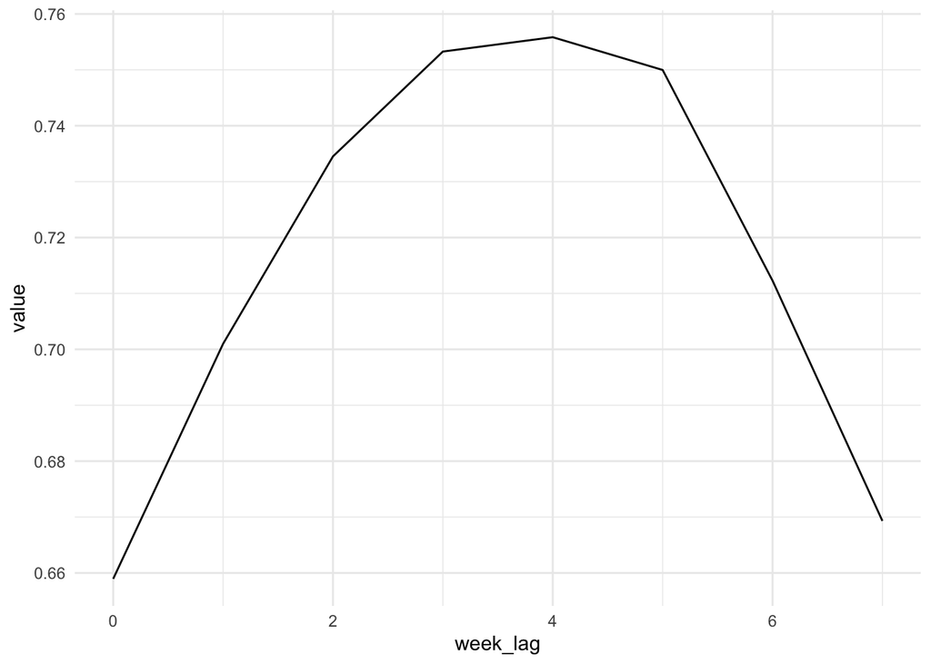

```r
covid %>%
  filter(wday(date) == 1) %>%
  group_by(fips, state) %>%
  mutate(cases_new = cases - lag(cases), deaths_new = deaths - lag(deaths)) %>%
  mutate(
    cases_new_0 = cases_new,
    cases_new_1 = lag(cases_new, n = 1),
    cases_new_2 = lag(cases_new, n = 2),
    cases_new_3 = lag(cases_new, n = 3),
    cases_new_4 = lag(cases_new, n = 4),
    cases_new_5 = lag(cases_new, n = 5),
    cases_new_6 = lag(cases_new, n = 6),
    cases_new_7 = lag(cases_new, n = 7)
  ) %>%
  ungroup() %>%
  summarise(
    sm_cor(deaths_new, cases_new_0),
    sm_cor(deaths_new, cases_new_1),
    sm_cor(deaths_new, cases_new_2),
    sm_cor(deaths_new, cases_new_3),
    sm_cor(deaths_new, cases_new_4),
    sm_cor(deaths_new, cases_new_5),
    sm_cor(deaths_new, cases_new_6),
    sm_cor(deaths_new, cases_new_7)
  ) %>%
  pivot_longer(cols = everything()) %>%
  mutate(week_lag = as.numeric(stri_extract(name, regex = "[0-9]"))) %>%
  ggplot(aes(week_lag, value)) +
    geom_line()
```

**Bonus** The code below is an modification/extension of question 5 that includes three changes: it uses 7-day rolling averages, computes the daily lags rather than weekly lags, and uses a weighted correlation as a function of the population. To do this without copying a lot of code, I use a for loop to cycle over each of the lags. In both plots you can see that deaths lag behind cases by about 3-4 weeks.

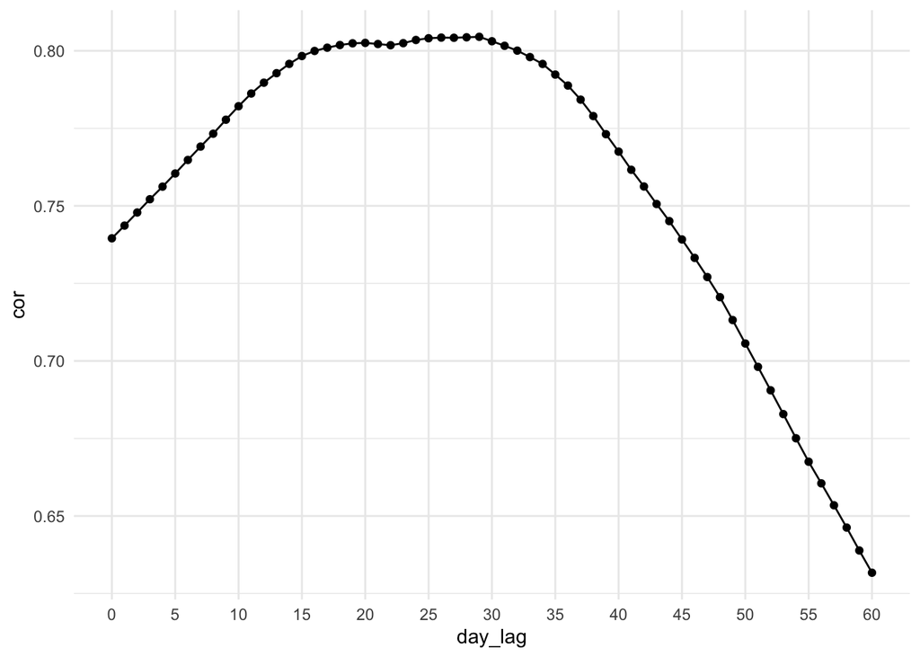

```r
covid_new <- covid %>%
  group_by(fips, state) %>%
  mutate(cases_new = cases - lag(cases), deaths_new = deaths - lag(deaths)) %>%
  mutate(
    cases_new = roll_meanr(cases_new, n = 7),
    deaths_new = roll_meanr(deaths_new, n = 7),
  ) %>%
  inner_join(demog, by = c("fips", "state")) %>%
  group_by(fips)

lag_data <- tibble(day_lag = seq(0, 60), cor = NA_real_)
for (j in seq_len(nrow(lag_data)))
{
  covid_new <- mutate(covid_new, cases_new_lag = lag(cases_new, n = j - 1))

  X <- as.matrix(select(ungroup(covid_new), deaths_new, cases_new_lag, population))
  X <- X[apply(!is.na(X), 1, all),]
  lag_data$cor[j] <- cov.wt(X[, 1:2], wt = X[, 3], cor = TRUE)$cor[1, 2]
}

lag_data %>%
  ggplot(aes(day_lag, cor)) +
    geom_point() +
    geom_line() +
    scale_x_continuous(breaks = seq(0, 60, by = 5), minor_breaks = NULL)
```